# p7_01_preparation

```python
import pandas as pd
import numpy as np
import matplotlib.pyplot as plt
import seaborn as sns

from sklearn.cluster import KMeans
from scipy.spatial.distance import cdist
from sklearn import decomposition, preprocessing


data = pd.read_csv("data-projet7.csv", decimal=",")
pop = pd.read_csv("population2004_2011.csv")
```

## I Nettoyage des Données

```python
data
```

|  | country | year_survey | quantile | nb_quantiles | income | gdpppp |
| --- | --- | --- | --- | --- | --- | --- |
| 0 | ALB | 2008 | 1 | 100 | 728.89795 | 7297.00000 |
| 1 | ALB | 2008 | 2 | 100 | 916.66235 | 7297.00000 |
| 2 | ALB | 2008 | 3 | 100 | 1010.91600 | 7297.00000 |
| 3 | ALB | 2008 | 4 | 100 | 1086.90780 | 7297.00000 |
| 4 | ALB | 2008 | 5 | 100 | 1132.69970 | 7297.00000 |
| ... | ... | ... | ... | ... | ... | ... |
| 11594 | COD | 2008 | 96 | 100 | 810.62330 | 303.19305 |
| 11595 | COD | 2008 | 97 | 100 | 911.78340 | 303.19305 |
| 11596 | COD | 2008 | 98 | 100 | 1057.80740 | 303.19305 |
| 11597 | COD | 2008 | 99 | 100 | 1286.60290 | 303.19305 |
| 11598 | COD | 2008 | 100 | 100 | 2243.12260 | 303.19305 |

11599 rows × 6 columns

```python
data_miss = data[data.isna().any(axis=1)]
print(data_miss.country.unique())
data_miss.info()
```

```
['XKX' 'PSE']
<class 'pandas.core.frame.DataFrame'>
Int64Index: 200 entries, 5800 to 11298
Data columns (total 6 columns):
 #   Column        Non-Null Count  Dtype
---  ------        --------------  -----
 0   country       200 non-null    object
 1   year_survey   200 non-null    int64
 2   quantile      200 non-null    int64
 3   nb_quantiles  200 non-null    int64
 4   income        200 non-null    float64
 5   gdpppp        0 non-null      float64
dtypes: float64(2), int64(3), object(1)
memory usage: 10.9+ KB
```

Il manque 200 valeurs pour le gdpppp, ce qui correspond à deux pays : XKX correspond au Kosovo et PSE correspond à la Palestine.

```python
# Imputation des gdpppp des deux pays
gdpppp_XKX_2008 = 7.367 # source : https://www.imf.org/external/datamapper/PPPPC@WEO/OEMDC/ADVEC/WEOWORLD/TUN
gdpppp_PSE_2008 = 3.324

data.loc[data["country"] == "PSE", ["gdpppp"]] = gdpppp_PSE_2008
data.loc[data["country"] == "XKX", ["gdpppp"]] = gdpppp_XKX_2008
```

```python
print(data.year_survey.unique())
print(data.year_survey.count())
print(data.country.value_counts())
```

```
[2008 2009 2010 2007 2006 2011 2004]
11599
GTM    100
JOR    100
URY    100
EST    100
POL    100
      ...
MEX    100
BGR    100
ALB    100
KAZ    100
LTU     99
Name: country, Length: 116, dtype: int64
```

Le fichier csv contient les années de 2004 à 2011, sauf, étonnamment, 2005.  
Il y a 116 pays différents dans le jeu de données.  
PROBLEME : j'ai 11 599 lignes pour 116 pays : il doit manquer des centiles pour certains pays.

```python
# Je vérifie que chaque pays contient bien 100 centiles
nb_centiles = data.groupby("country").count()
nb_centiles = pd.DataFrame(nb_centiles)
nb_centiles.reset_index(inplace=True)

nb_centiles.loc[nb_centiles["quantile"] != 100]
```

|  | country | year_survey | quantile | nb_quantiles | income | gdpppp |
| --- | --- | --- | --- | --- | --- | --- |
| 62 | LTU | 99 | 99 | 99 | 99 | 99 |

Seule la Lituanie n'a pas ses 100 quantiles. Il en manque un.

```python
del nb_centiles
```

```python
pd.set_option('display.max_rows', 100)

data.loc[data["country"]=="LTU"]
```

|  | country | year_survey | quantile | nb_quantiles | income | gdpppp |
| --- | --- | --- | --- | --- | --- | --- |
| 6200 | LTU | 2008 | 1 | 100 | 566.3453 | 17571.0 |
| 6201 | LTU | 2008 | 2 | 100 | 1147.0587 | 17571.0 |
| 6202 | LTU | 2008 | 3 | 100 | 1490.8408 | 17571.0 |
| 6203 | LTU | 2008 | 4 | 100 | 1746.5715 | 17571.0 |
| 6204 | LTU | 2008 | 5 | 100 | 1842.9542 | 17571.0 |
| 6205 | LTU | 2008 | 6 | 100 | 1925.8641 | 17571.0 |
| 6206 | LTU | 2008 | 7 | 100 | 2048.3857 | 17571.0 |
| 6207 | LTU | 2008 | 8 | 100 | 2173.7112 | 17571.0 |
| 6208 | LTU | 2008 | 9 | 100 | 2302.0857 | 17571.0 |
| 6209 | LTU | 2008 | 10 | 100 | 2361.6480 | 17571.0 |
| 6210 | LTU | 2008 | 11 | 100 | 2452.7578 | 17571.0 |
| 6211 | LTU | 2008 | 12 | 100 | 2602.3857 | 17571.0 |
| 6212 | LTU | 2008 | 13 | 100 | 2732.9660 | 17571.0 |
| 6213 | LTU | 2008 | 14 | 100 | 2849.0960 | 17571.0 |
| 6214 | LTU | 2008 | 15 | 100 | 3010.8962 | 17571.0 |
| 6215 | LTU | 2008 | 16 | 100 | 3121.6091 | 17571.0 |
| 6216 | LTU | 2008 | 17 | 100 | 3174.2260 | 17571.0 |
| 6217 | LTU | 2008 | 18 | 100 | 3264.4023 | 17571.0 |
| 6218 | LTU | 2008 | 19 | 100 | 3338.4468 | 17571.0 |
| 6219 | LTU | 2008 | 20 | 100 | 3405.9260 | 17571.0 |
| 6220 | LTU | 2008 | 21 | 100 | 3516.2354 | 17571.0 |
| 6221 | LTU | 2008 | 22 | 100 | 3588.2507 | 17571.0 |
| 6222 | LTU | 2008 | 23 | 100 | 3673.9355 | 17571.0 |
| 6223 | LTU | 2008 | 24 | 100 | 3781.4660 | 17571.0 |
| 6224 | LTU | 2008 | 25 | 100 | 3864.0430 | 17571.0 |
| 6225 | LTU | 2008 | 26 | 100 | 3930.2112 | 17571.0 |
| 6226 | LTU | 2008 | 27 | 100 | 3990.3855 | 17571.0 |
| 6227 | LTU | 2008 | 28 | 100 | 4048.9220 | 17571.0 |
| 6228 | LTU | 2008 | 29 | 100 | 4109.7764 | 17571.0 |
| 6229 | LTU | 2008 | 30 | 100 | 4190.6610 | 17571.0 |

[output cut: 69 more lines]

Il manque le quantile 41 à la Lituanie.  
Je l'impute à partir des quantiles 40 et 42.

```python
# Imputation de la valeur manquante pour LTU

bornes_quantile_manquant = [6239, 6240]
income_quantile_41 = (data.loc[bornes_quantile_manquant[0], "income"] + data.loc[bornes_quantile_manquant[1],
                                                                                 "income"])/2
income_quantile_41
```

```
4882.14065
```

```python
imputed_quantile = data.loc[bornes_quantile_manquant[0]]
missing_quantile = 41
imputed_quantile = dict(imputed_quantile)
imputed_quantile["quantile"] = missing_quantile
imputed_quantile["income"] = income_quantile_41
imputed_quantile

data = data.append(imputed_quantile, ignore_index=True)
```

```python
# Affichage du nombre de pays en fonction de l'année

countries_per_year = data.groupby("year_survey").count()
countries_per_year = pd.DataFrame(countries_per_year)
countries_per_year.reset_index(inplace=True)
countries_per_year["country"] = countries_per_year["country"]/100
countries_per_year[["year_survey","country"]]
```

|  | year_survey | country |
| --- | --- | --- |
| 0 | 2004 | 1.0 |
| 1 | 2006 | 5.0 |
| 2 | 2007 | 15.0 |
| 3 | 2008 | 76.0 |
| 4 | 2009 | 12.0 |
| 5 | 2010 | 6.0 |
| 6 | 2011 | 1.0 |

2008 est à la fois l'année qui correspond au plus grand nombre de données, et l'année la plus centrale de l'échantillon.

```python
# Préparation du merge

pop = pop[["Code zone", "Année", "Valeur"]]
pop.Valeur = pop.Valeur*1000
pop.rename(columns={"Code zone":"country", "Année":"year_survey", "Valeur": "population"}, inplace=True)
pop.head(3)
```

|  | country | year_survey | population |
| --- | --- | --- | --- |
| 0 | AFG | 2004 | 24726684.0 |
| 1 | AFG | 2005 | 25654277.0 |
| 2 | AFG | 2006 | 26433049.0 |

```python
# Merge
data = pd.merge(data, pop, on=["year_survey","country"], how='left')
data
```

|  | country | year_survey | quantile | nb_quantiles | income | gdpppp | population |
| --- | --- | --- | --- | --- | --- | --- | --- |
| 0 | ALB | 2008 | 1 | 100 | 728.89795 | 7297.00000 | 3002678.0 |
| 1 | ALB | 2008 | 2 | 100 | 916.66235 | 7297.00000 | 3002678.0 |
| 2 | ALB | 2008 | 3 | 100 | 1010.91600 | 7297.00000 | 3002678.0 |
| 3 | ALB | 2008 | 4 | 100 | 1086.90780 | 7297.00000 | 3002678.0 |
| 4 | ALB | 2008 | 5 | 100 | 1132.69970 | 7297.00000 | 3002678.0 |
| ... | ... | ... | ... | ... | ... | ... | ... |
| 11595 | COD | 2008 | 97 | 100 | 911.78340 | 303.19305 | 60411195.0 |
| 11596 | COD | 2008 | 98 | 100 | 1057.80740 | 303.19305 | 60411195.0 |
| 11597 | COD | 2008 | 99 | 100 | 1286.60290 | 303.19305 | 60411195.0 |
| 11598 | COD | 2008 | 100 | 100 | 2243.12260 | 303.19305 | 60411195.0 |
| 11599 | LTU | 2008 | 41 | 100 | 4882.14065 | 17571.00000 | 3212865.0 |

11600 rows × 7 columns

```python
data[data.isna().any(axis=1)]
```

|  | country | year_survey | quantile | nb_quantiles | income | gdpppp | population |
| --- | --- | --- | --- | --- | --- | --- | --- |
| 5800 | XKX | 2008 | 1 | 100 | 437.89370 | 7.367 | NaN |
| 5801 | XKX | 2008 | 2 | 100 | 508.17133 | 7.367 | NaN |
| 5802 | XKX | 2008 | 3 | 100 | 591.82820 | 7.367 | NaN |
| 5803 | XKX | 2008 | 4 | 100 | 668.00000 | 7.367 | NaN |
| 5804 | XKX | 2008 | 5 | 100 | 730.40220 | 7.367 | NaN |
| ... | ... | ... | ... | ... | ... | ... | ... |
| 9294 | SDN | 2009 | 96 | 100 | 2545.85800 | 2345.000 | NaN |
| 9295 | SDN | 2009 | 97 | 100 | 2786.10100 | 2345.000 | NaN |
| 9296 | SDN | 2009 | 98 | 100 | 3021.93480 | 2345.000 | NaN |
| 9297 | SDN | 2009 | 99 | 100 | 3548.41850 | 2345.000 | NaN |
| 9298 | SDN | 2009 | 100 | 100 | 5336.52400 | 2345.000 | NaN |

200 rows × 7 columns

Il manque les valeurs pour la population pour le Kosovo (XKX) et le Soudan (SDN).

```python
# Imputation des données manquantes sur la colonne "population"

pop_XKX_2008 = 1761474  # https://data.worldbank.org/indicator/SP.POP.TOTL?locations=XK
pop_SDN_2008 = 33060397 # https://data.worldbank.org/indicator/SP.POP.TOTL?locations=SD

data.loc[data["country"] == "XKX", ["population"]] = pop_XKX_2008
data.loc[data["country"] == "SDN", ["population"]] = pop_SDN_2008
```

```python
temp=data.groupby("country").agg({"population":max})
temp = pd.DataFrame(temp)
temp.reset_index(inplace=True)

POP_MOND_2010 = 6956824000 # source : https://fr.wikipedia.org/wiki/Population_mondiale
print("La population couverte par l'analyse est de {} %.".format(temp.population.sum()/ POP_MOND_2010*100))
del temp
```

```
La population couverte par l'analyse est de 89.81839428451833 %.
```

```python
# Création d'une boucle qui calcule les indices de Gini pour chaque pays

gini_countries = []
n = 100

for country in data.country :
    lorenz_country = data.loc[data.country==country].income.values
    lorenz = np.cumsum(np.sort(lorenz_country)) / lorenz_country.sum()
    lorenz = np.append([0],lorenz) # La courbe de Lorenz commence à 0
    AUC = (lorenz.sum() -lorenz[-1]/2 -lorenz[0]/2)/n
    S = 0.5 - AUC # surface entre la première bissectrice et la courbe de Lorenz
    gini = 2*S
    gini_countries.append(gini)

# Ajout des indices de Gini à une colonne de "data"
data["gini"] = gini_countries
data
```

|  | country | year_survey | quantile | nb_quantiles | income | gdpppp | population | gini |
| --- | --- | --- | --- | --- | --- | --- | --- | --- |
| 0 | ALB | 2008 | 1 | 100 | 728.89795 | 7297.00000 | 3002678.0 | 0.304624 |
| 1 | ALB | 2008 | 2 | 100 | 916.66235 | 7297.00000 | 3002678.0 | 0.304624 |
| 2 | ALB | 2008 | 3 | 100 | 1010.91600 | 7297.00000 | 3002678.0 | 0.304624 |
| 3 | ALB | 2008 | 4 | 100 | 1086.90780 | 7297.00000 | 3002678.0 | 0.304624 |
| 4 | ALB | 2008 | 5 | 100 | 1132.69970 | 7297.00000 | 3002678.0 | 0.304624 |
| ... | ... | ... | ... | ... | ... | ... | ... | ... |
| 11595 | COD | 2008 | 97 | 100 | 911.78340 | 303.19305 | 60411195.0 | 0.443997 |
| 11596 | COD | 2008 | 98 | 100 | 1057.80740 | 303.19305 | 60411195.0 | 0.443997 |
| 11597 | COD | 2008 | 99 | 100 | 1286.60290 | 303.19305 | 60411195.0 | 0.443997 |
| 11598 | COD | 2008 | 100 | 100 | 2243.12260 | 303.19305 | 60411195.0 | 0.443997 |
| 11599 | LTU | 2008 | 41 | 100 | 4882.14065 | 17571.00000 | 3212865.0 | 0.334528 |

11600 rows × 8 columns

#### Réponse aux questions de la Mission 1

- Il y a cent quantiles pour chaque pays et chaque année : il s'agit donc de centiles
- Echantillonner une population en utilisant des quantiles est une bonne méthode car elle permet d'avoir une appréhension complexe de cette population, qui n'est pas vue comme un tout artificiellement homogène, mais au contraire comme une succession de couches sociales. C'est une vraie diversité et pas une fausse unité. Et cela permet de rester davantage proche des données initiales, récoltées sur le terrain. On peut toujours aller vers l'abstraction par la suite en réunissant ces données.

-- Unité PPP : il s'agit du PIB à PPA, à parité de pouvoir d'achat : c'est un indice créé pour comparer le pouvoir d'achat dans les différents pays du monde, en faisant la synthèse du prix du panier d'achat et du salaire. Tout cela est ramené à un score : plus il est élevé, plus le pouvoir d'achat moyen est grand dans un pays.

```python
data.describe()
```

|  | year_survey | quantile | nb_quantiles | income | gdpppp | population | gini |
| --- | --- | --- | --- | --- | --- | --- | --- |
| count | 11600.000000 | 11600.000000 | 11600.0 | 11600.000000 | 1.160000e+04 | 1.160000e+04 | 11600.000000 |
| mean | 2007.982759 | 50.500000 | 100.0 | 6069.121925 | 4.935267e+04 | 5.386644e+07 | 0.378967 |
| std | 0.909593 | 28.867314 | 0.0 | 9413.786596 | 3.966412e+05 | 1.702133e+08 | 0.089397 |
| min | 2004.000000 | 1.000000 | 100.0 | 16.719418 | 3.324000e+00 | 3.108560e+05 | 0.230731 |
| 25% | 2008.000000 | 25.750000 | 100.0 | 900.768508 | 2.342500e+03 | 4.694046e+06 | 0.310420 |
| 50% | 2008.000000 | 50.500000 | 100.0 | 2403.492950 | 7.532500e+03 | 1.453768e+07 | 0.360893 |
| 75% | 2008.000000 | 75.250000 | 100.0 | 7515.313700 | 1.819625e+04 | 3.904949e+07 | 0.435908 |
| max | 2011.000000 | 100.000000 | 100.0 | 176928.550000 | 4.300332e+06 | 1.376266e+09 | 0.669779 |

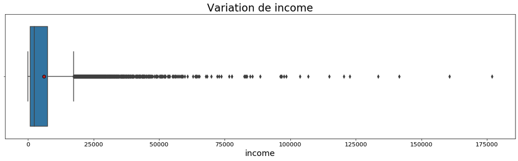

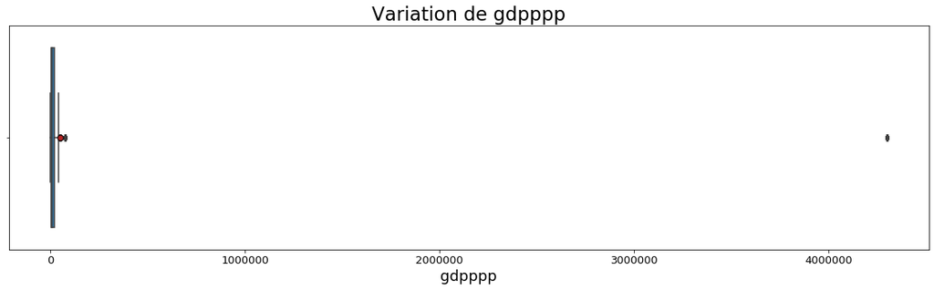

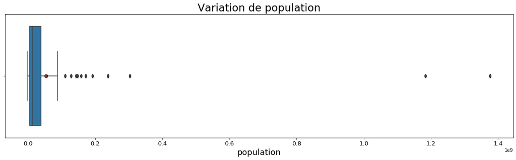

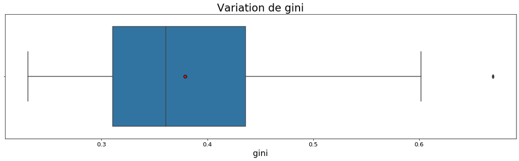

```python
meanprops = {'marker':'o', 'markeredgecolor':'black',
            'markerfacecolor':'firebrick', "markersize":'7'}

data_boxplots = data[["income", "gdpppp", "population", "gini"]]

for columns in data_boxplots :
    plt.figure(figsize=(20,5))
    sns.boxplot(x=columns, data=data_boxplots, showmeans=True, meanprops=meanprops, orient="h")
    plt.title('Variation de {}'.format(columns), fontsize='23')
    plt.xlabel('{}'.format(columns), fontsize='18')
    plt.xticks(fontsize=13)
    plt.show()
```

J'observe un outlier sur le boxplot du gdpppp.  
Les autres boxplots ne montrent pas de donnée surprenante.

```python
gdpppp_outlier = data.gdpppp.max()
data.loc[data.gdpppp == gdpppp_outlier]
```

|  | country | year_survey | quantile | nb_quantiles | income | gdpppp | population | gini |
| --- | --- | --- | --- | --- | --- | --- | --- | --- |
| 3200 | FJI | 2008 | 1 | 100 | 308.17334 | 4300332.0 | 845361.0 | 0.428221 |
| 3201 | FJI | 2008 | 2 | 100 | 384.33230 | 4300332.0 | 845361.0 | 0.428221 |
| 3202 | FJI | 2008 | 3 | 100 | 436.59265 | 4300332.0 | 845361.0 | 0.428221 |
| 3203 | FJI | 2008 | 4 | 100 | 486.81436 | 4300332.0 | 845361.0 | 0.428221 |
| 3204 | FJI | 2008 | 5 | 100 | 520.19720 | 4300332.0 | 845361.0 | 0.428221 |
| 3205 | FJI | 2008 | 6 | 100 | 556.57300 | 4300332.0 | 845361.0 | 0.428221 |
| 3206 | FJI | 2008 | 7 | 100 | 579.09064 | 4300332.0 | 845361.0 | 0.428221 |
| 3207 | FJI | 2008 | 8 | 100 | 598.60050 | 4300332.0 | 845361.0 | 0.428221 |
| 3208 | FJI | 2008 | 9 | 100 | 624.10980 | 4300332.0 | 845361.0 | 0.428221 |
| 3209 | FJI | 2008 | 10 | 100 | 646.52160 | 4300332.0 | 845361.0 | 0.428221 |
| 3210 | FJI | 2008 | 11 | 100 | 677.46246 | 4300332.0 | 845361.0 | 0.428221 |
| 3211 | FJI | 2008 | 12 | 100 | 702.57587 | 4300332.0 | 845361.0 | 0.428221 |
| 3212 | FJI | 2008 | 13 | 100 | 722.34076 | 4300332.0 | 845361.0 | 0.428221 |
| 3213 | FJI | 2008 | 14 | 100 | 739.43835 | 4300332.0 | 845361.0 | 0.428221 |
| 3214 | FJI | 2008 | 15 | 100 | 756.93180 | 4300332.0 | 845361.0 | 0.428221 |
| 3215 | FJI | 2008 | 16 | 100 | 775.38180 | 4300332.0 | 845361.0 | 0.428221 |
| 3216 | FJI | 2008 | 17 | 100 | 793.71050 | 4300332.0 | 845361.0 | 0.428221 |
| 3217 | FJI | 2008 | 18 | 100 | 810.72680 | 4300332.0 | 845361.0 | 0.428221 |
| 3218 | FJI | 2008 | 19 | 100 | 826.53450 | 4300332.0 | 845361.0 | 0.428221 |
| 3219 | FJI | 2008 | 20 | 100 | 850.97406 | 4300332.0 | 845361.0 | 0.428221 |
| 3220 | FJI | 2008 | 21 | 100 | 878.08295 | 4300332.0 | 845361.0 | 0.428221 |
| 3221 | FJI | 2008 | 22 | 100 | 896.53530 | 4300332.0 | 845361.0 | 0.428221 |
| 3222 | FJI | 2008 | 23 | 100 | 919.48880 | 4300332.0 | 845361.0 | 0.428221 |
| 3223 | FJI | 2008 | 24 | 100 | 938.87146 | 4300332.0 | 845361.0 | 0.428221 |
| 3224 | FJI | 2008 | 25 | 100 | 955.34973 | 4300332.0 | 845361.0 | 0.428221 |
| 3225 | FJI | 2008 | 26 | 100 | 974.70590 | 4300332.0 | 845361.0 | 0.428221 |
| 3226 | FJI | 2008 | 27 | 100 | 994.94020 | 4300332.0 | 845361.0 | 0.428221 |
| 3227 | FJI | 2008 | 28 | 100 | 1011.56240 | 4300332.0 | 845361.0 | 0.428221 |
| 3228 | FJI | 2008 | 29 | 100 | 1031.52730 | 4300332.0 | 845361.0 | 0.428221 |
| 3229 | FJI | 2008 | 30 | 100 | 1049.11670 | 4300332.0 | 845361.0 | 0.428221 |

[output cut: 70 more lines]

Il s'agit des îles Fidji. Je remplace le gdpppp par celui qui est correct.

```python
# Imputation du gdpppp correct
gdpppp_FJI_2008 = 8460
data.loc[data["country"] == "FJI", ["gdpppp"]] = gdpppp_FJI_2008
```

## II Préparation des données pour la MISSION 2

```python
# Je sélectionne la colonne gdpppp, qui me donne un indice moyen de la richesse par habitant, et l'indice de
# gini, qui me donne un indice sur la répartition de cette richesse dans le pays

data_kmeans = data.groupby('gdpppp').agg({'gini':max})
data_kmeans=pd.DataFrame(data_kmeans)
data_kmeans.reset_index(inplace=True)
data_kmeans
```

|  | gdpppp | gini |
| --- | --- | --- |
| 0 | 3.32400 | 0.355068 |
| 1 | 7.36700 | 0.314475 |
| 2 | 303.19305 | 0.443997 |
| 3 | 372.00000 | 0.380872 |
| 4 | 631.00000 | 0.373104 |
| ... | ... | ... |
| 111 | 38065.00000 | 0.287792 |
| 112 | 39268.00000 | 0.303440 |
| 113 | 43261.00000 | 0.431799 |
| 114 | 49070.00000 | 0.262948 |
| 115 | 73127.00000 | 0.292935 |

116 rows × 2 columns

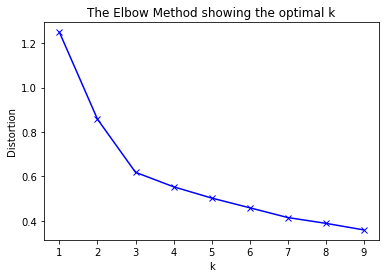

```python
# Application d'un algorithme de classification pour déterminer des pays représentatifs des classes de revenu

# Sélection des données numérique du df
X = data_kmeans

# Centrage et Réduction
X_scaled = preprocessing.StandardScaler().fit_transform(X)
X = X_scaled.copy()

distortions = []
K = range(1,10)
for k in K:
    kmeanModel = KMeans(n_clusters=k).fit(X)
    kmeanModel.fit(X)
    distortions.append(sum(np.min(cdist(X, kmeanModel.cluster_centers_, 'euclidean'), axis=1)) / X.shape[0])

# Représentation graphique
plt.plot(K, distortions, 'bx-')
plt.xlabel('k')
plt.ylabel('Distortion')
plt.title('The Elbow Method showing the optimal k')

plt.savefig("images_soutenance/mission1_elbow.jpeg", format="jpeg")
```

Le résultat n'est pas très clair. La courbe s'infléchit nettement à k=3. On peut toutefois voir deux autres légers infléchissements pour k=7 ou k=9. Je choisis k=7 pour avoir de la marge pour ajouter les pays extrêmes (le mieux classé et le moins bien classé).

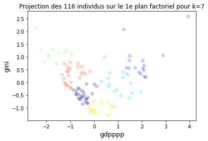

```python
# Application de l'algorithme K-means

from fanalysis.pca import PCA


# Calcul des composantes principales
n_comp = 2
pca = decomposition.PCA(n_components=n_comp)
pca.fit(X_scaled)

# Nombre de clusters souhaités
n_clust = 7

# Clustering par K-means
km = KMeans(n_clusters=n_clust)
km.fit(X)

# Récupération des clusters attribués à chaque individu
clusters = km.labels_

# Affichage du clustering par projection des individus sur le premier plan factoriel
pca = decomposition.PCA(n_components=n_comp).fit(X)
X_projected = pca.transform(X)
plt.scatter(X_projected[:, 0], X_projected[:, 1], c=clusters.astype(np.float), cmap = 'jet', alpha=.2)
plt.title("Projection des {} individus sur le 1e plan factoriel pour k=7".format(X_projected.shape[0]))
plt.xlabel("gdpppp", fontsize=13)
plt.ylabel("gini", fontsize=13)

plt.savefig("images_soutenance/mission1_kmeans.jpeg", format="jpeg")
```

```python
# Création d'une colonne établissant les groupes de pays d'après le K-means
data_kmeans["cluster"]=clusters
```

```python
# Ajout de cette colonne au df principal
data = pd.merge(data, data_kmeans, on=["gdpppp", "gini"], how="left")
data
```

|  | country | year_survey | quantile | nb_quantiles | income | gdpppp | population | gini | cluster |
| --- | --- | --- | --- | --- | --- | --- | --- | --- | --- |
| 0 | ALB | 2008 | 1 | 100 | 728.89795 | 7297.00000 | 3002678.0 | 0.304624 | 4 |
| 1 | ALB | 2008 | 2 | 100 | 916.66235 | 7297.00000 | 3002678.0 | 0.304624 | 4 |
| 2 | ALB | 2008 | 3 | 100 | 1010.91600 | 7297.00000 | 3002678.0 | 0.304624 | 4 |
| 3 | ALB | 2008 | 4 | 100 | 1086.90780 | 7297.00000 | 3002678.0 | 0.304624 | 4 |
| 4 | ALB | 2008 | 5 | 100 | 1132.69970 | 7297.00000 | 3002678.0 | 0.304624 | 4 |
| ... | ... | ... | ... | ... | ... | ... | ... | ... | ... |
| 11595 | COD | 2008 | 97 | 100 | 911.78340 | 303.19305 | 60411195.0 | 0.443997 | 5 |
| 11596 | COD | 2008 | 98 | 100 | 1057.80740 | 303.19305 | 60411195.0 | 0.443997 | 5 |
| 11597 | COD | 2008 | 99 | 100 | 1286.60290 | 303.19305 | 60411195.0 | 0.443997 | 5 |
| 11598 | COD | 2008 | 100 | 100 | 2243.12260 | 303.19305 | 60411195.0 | 0.443997 | 5 |
| 11599 | LTU | 2008 | 41 | 100 | 4882.14065 | 17571.00000 | 3212865.0 | 0.334528 | 2 |

11600 rows × 9 columns

```python
# Affichage des pays contenus dans chaque cluster
temp=data.groupby("country").agg({"cluster":max})
temp = pd.DataFrame(temp)
temp.reset_index(inplace=True)

for i in range(0,n_clust):
    print("groupe {}".format(i))
    print(", ".join(temp.country[temp.cluster==i]))
```

```
groupe 0
BFA, BGR, BIH, BTN, CIV, CMR, GEO, GIN, IDN, IRQ, KGZ, LAO, LBR, LKA, MAR, MKD, MNG, MRT, NER, PSE, ROU, SDN, SYR, TZA, VNM, YEM
groupe 1
AUT, BEL, CAN, DEU, DNK, FIN, FRA, GBR, IRL, ISL, JPN, NLD, NOR, SWE, USA
groupe 2
CYP, CZE, ESP, EST, GRC, HRV, HUN, ISR, ITA, KOR, LTU, LVA, POL, PRT, SVK, SVN, TWN
groupe 3
BOL, BRA, CAF, CHL, COL, ECU, GTM, HND, MEX, PAN, PRY, ZAF
groupe 4
ALB, ARM, AZE, BGD, BLR, EGY, IND, JOR, KAZ, KEN, KHM, MDA, MLI, MNE, NPL, PAK, SRB, TJK, TLS, UKR, XKX
groupe 5
ARG, CHN, COD, CRI, DOM, FJI, GHA, IRN, MDG, MOZ, MWI, MYS, NGA, NIC, PER, PHL, RUS, SLV, SWZ, THA, TUR, UGA, URY, VEN
groupe 6
LUX
```

```python
# Pour chaque cluster, choix des pays pour lesquels le plus d'indices de Gini est disponible

gini_1960_2020 = pd.read_csv("gini.csv", sep=',')
gini_2004_2011 = gini_1960_2020[["Country_Code","Country_Name","2004","2005","2006","2007","2008","2009",
                                        "2010", "2011"]] # Sélection des années de l'étude
del gini_1960_2020
gini_2004_2011.set_index("Country_Code", inplace=True)
gini_2004_2011
```

| Country_Code | Country_Name | 2004 | 2005 | 2006 | 2007 | 2008 | 2009 | 2010 | 2011 |
| --- | --- | --- | --- | --- | --- | --- | --- | --- | --- |
| ABW | Aruba | NaN | NaN | NaN | NaN | NaN | NaN | NaN | NaN |
| AFG | Afghanistan | NaN | NaN | NaN | NaN | NaN | NaN | NaN | NaN |
| AGO | Angola | NaN | NaN | NaN | NaN | 42.7 | NaN | NaN | NaN |
| ALB | Albania | NaN | 30.6 | NaN | NaN | 30.0 | NaN | NaN | NaN |
| AND | Andorra | NaN | NaN | NaN | NaN | NaN | NaN | NaN | NaN |
| ... | ... | ... | ... | ... | ... | ... | ... | ... | ... |
| XKX | Kosovo | NaN | 31.2 | 30.3 | NaN | NaN | 31.8 | 33.3 | 27.8 |
| YEM | Yemen_ Rep. | NaN | 34.7 | NaN | NaN | NaN | NaN | NaN | NaN |
| ZAF | South Africa | NaN | 64.8 | NaN | NaN | 63.0 | NaN | 63.4 | NaN |
| ZMB | Zambia | 54.3 | NaN | 54.6 | NaN | NaN | NaN | 55.6 | NaN |
| ZWE | Zimbabwe | NaN | NaN | NaN | NaN | NaN | NaN | NaN | 43.2 |

264 rows × 9 columns

```python
gini_transposed = gini_2004_2011.transpose()
gini_transposed
```

| Country_Code | ABW | AFG | AGO | ALB | AND | ARB | ARE | ARG | ARM | ASM | ... | VIR | VNM | VUT | WLD | WSM | XKX | YEM | ZAF | ZMB | ZWE |
| --- | --- | --- | --- | --- | --- | --- | --- | --- | --- | --- | --- | --- | --- | --- | --- | --- | --- | --- | --- | --- | --- |
| Country_Name | Aruba | Afghanistan | Angola | Albania | Andorra | Arab World | United Arab Emirates | Argentina | Armenia | American Samoa | ... | Virgin Islands (U.S.) | Vietnam | Vanuatu | World | Samoa | Kosovo | Yemen_ Rep. | South Africa | Zambia | Zimbabwe |
| 2004 | NaN | NaN | NaN | NaN | NaN | NaN | NaN | 48.6 | 37.5 | NaN | ... | NaN | 36.8 | NaN | NaN | NaN | NaN | NaN | NaN | 54.3 | NaN |
| 2005 | NaN | NaN | NaN | 30.6 | NaN | NaN | NaN | 48 | 36 | NaN | ... | NaN | NaN | NaN | NaN | NaN | 31.2 | 34.7 | 64.8 | NaN | NaN |
| 2006 | NaN | NaN | NaN | NaN | NaN | NaN | NaN | 46.7 | 29.7 | NaN | ... | NaN | 35.8 | NaN | NaN | NaN | 30.3 | NaN | NaN | 54.6 | NaN |
| 2007 | NaN | NaN | NaN | NaN | NaN | NaN | NaN | 46.6 | 31.2 | NaN | ... | NaN | NaN | NaN | NaN | NaN | NaN | NaN | NaN | NaN | NaN |
| 2008 | NaN | NaN | 42.7 | 30 | NaN | NaN | NaN | 45.3 | 29.2 | NaN | ... | NaN | 35.6 | NaN | NaN | 42 | NaN | NaN | 63 | NaN | NaN |
| 2009 | NaN | NaN | NaN | NaN | NaN | NaN | NaN | 44.1 | 28 | NaN | ... | NaN | NaN | NaN | NaN | NaN | 31.8 | NaN | NaN | NaN | NaN |
| 2010 | NaN | NaN | NaN | NaN | NaN | NaN | NaN | 44.5 | 30 | NaN | ... | NaN | 39.3 | 37.6 | NaN | NaN | 33.3 | NaN | 63.4 | 55.6 | NaN |
| 2011 | NaN | NaN | NaN | NaN | NaN | NaN | NaN | 42.7 | 29.4 | NaN | ... | NaN | NaN | NaN | NaN | NaN | 27.8 | NaN | NaN | NaN | 43.2 |

9 rows × 264 columns

```python
# DataFrame avec le compte des indices de gini disponibles pour chaque pays
count_val = gini_transposed.count()
count_val = pd.DataFrame(count_val)
count_val.reset_index(inplace=True)
count_val.columns=["country", "count_val"]


data = pd.merge(count_val, data, on="country", how="right")
data[data.isna().any(axis=1)]
```

|  | country | count_val | year_survey | quantile | nb_quantiles | income | gdpppp | population | gini | cluster |
| --- | --- | --- | --- | --- | --- | --- | --- | --- | --- | --- |
| 10400 | TWN | NaN | 2008 | 1 | 100 | 3477.1800 | 25342.0 | 23019045.0 | 0.314801 | 2 |
| 10401 | TWN | NaN | 2008 | 2 | 100 | 4740.2637 | 25342.0 | 23019045.0 | 0.314801 | 2 |
| 10402 | TWN | NaN | 2008 | 3 | 100 | 5331.3013 | 25342.0 | 23019045.0 | 0.314801 | 2 |
| 10403 | TWN | NaN | 2008 | 4 | 100 | 5761.6577 | 25342.0 | 23019045.0 | 0.314801 | 2 |
| 10404 | TWN | NaN | 2008 | 5 | 100 | 6093.2017 | 25342.0 | 23019045.0 | 0.314801 | 2 |
| 10405 | TWN | NaN | 2008 | 6 | 100 | 6406.4414 | 25342.0 | 23019045.0 | 0.314801 | 2 |
| 10406 | TWN | NaN | 2008 | 7 | 100 | 6659.2026 | 25342.0 | 23019045.0 | 0.314801 | 2 |
| 10407 | TWN | NaN | 2008 | 8 | 100 | 6918.4180 | 25342.0 | 23019045.0 | 0.314801 | 2 |
| 10408 | TWN | NaN | 2008 | 9 | 100 | 7112.2593 | 25342.0 | 23019045.0 | 0.314801 | 2 |
| 10409 | TWN | NaN | 2008 | 10 | 100 | 7308.3813 | 25342.0 | 23019045.0 | 0.314801 | 2 |
| 10410 | TWN | NaN | 2008 | 11 | 100 | 7496.1580 | 25342.0 | 23019045.0 | 0.314801 | 2 |
| 10411 | TWN | NaN | 2008 | 12 | 100 | 7681.5425 | 25342.0 | 23019045.0 | 0.314801 | 2 |
| 10412 | TWN | NaN | 2008 | 13 | 100 | 7850.1245 | 25342.0 | 23019045.0 | 0.314801 | 2 |
| 10413 | TWN | NaN | 2008 | 14 | 100 | 8009.6370 | 25342.0 | 23019045.0 | 0.314801 | 2 |
| 10414 | TWN | NaN | 2008 | 15 | 100 | 8181.0010 | 25342.0 | 23019045.0 | 0.314801 | 2 |
| 10415 | TWN | NaN | 2008 | 16 | 100 | 8341.2930 | 25342.0 | 23019045.0 | 0.314801 | 2 |
| 10416 | TWN | NaN | 2008 | 17 | 100 | 8513.5470 | 25342.0 | 23019045.0 | 0.314801 | 2 |
| 10417 | TWN | NaN | 2008 | 18 | 100 | 8659.8730 | 25342.0 | 23019045.0 | 0.314801 | 2 |
| 10418 | TWN | NaN | 2008 | 19 | 100 | 8803.5850 | 25342.0 | 23019045.0 | 0.314801 | 2 |
| 10419 | TWN | NaN | 2008 | 20 | 100 | 8945.7950 | 25342.0 | 23019045.0 | 0.314801 | 2 |
| 10420 | TWN | NaN | 2008 | 21 | 100 | 9087.1140 | 25342.0 | 23019045.0 | 0.314801 | 2 |
| 10421 | TWN | NaN | 2008 | 22 | 100 | 9223.2590 | 25342.0 | 23019045.0 | 0.314801 | 2 |
| 10422 | TWN | NaN | 2008 | 23 | 100 | 9366.3030 | 25342.0 | 23019045.0 | 0.314801 | 2 |
| 10423 | TWN | NaN | 2008 | 24 | 100 | 9521.4770 | 25342.0 | 23019045.0 | 0.314801 | 2 |
| 10424 | TWN | NaN | 2008 | 25 | 100 | 9658.3450 | 25342.0 | 23019045.0 | 0.314801 | 2 |
| 10425 | TWN | NaN | 2008 | 26 | 100 | 9810.9580 | 25342.0 | 23019045.0 | 0.314801 | 2 |
| 10426 | TWN | NaN | 2008 | 27 | 100 | 9952.5000 | 25342.0 | 23019045.0 | 0.314801 | 2 |
| 10427 | TWN | NaN | 2008 | 28 | 100 | 10069.6730 | 25342.0 | 23019045.0 | 0.314801 | 2 |
| 10428 | TWN | NaN | 2008 | 29 | 100 | 10224.5680 | 25342.0 | 23019045.0 | 0.314801 | 2 |
| 10429 | TWN | NaN | 2008 | 30 | 100 | 10362.6600 | 25342.0 | 23019045.0 | 0.314801 | 2 |

[output cut: 70 more lines]

Il n'y a pas de recension d'indices de Gini pour Taiwan. On impute donc la valeur 0.

```python
# On impute la valeur 0 pour Taiwan
data.loc[data["country"] == "TWN", ["count_val"]] = 0
```

```python
# Dataframe avec seulement les pays contenant le maximum d'indices de gini pour chaque cluster
best_count = data.set_index("country").groupby(["cluster"]).agg({"count_val":max})
best_count = pd.DataFrame(best_count)
best_count.reset_index(inplace=True)

best_countries = pd.merge(data, best_count, on=["cluster", "count_val"], how='right')

data = pd.merge(data, best_count, on=["cluster", "count_val"], how='left')
data
```

|  | country | count_val | year_survey | quantile | nb_quantiles | income | gdpppp | population | gini | cluster |
| --- | --- | --- | --- | --- | --- | --- | --- | --- | --- | --- |
| 0 | ALB | 3.0 | 2008 | 1 | 100 | 728.89795 | 7297.00000 | 3002678.0 | 0.304624 | 4 |
| 1 | ALB | 3.0 | 2008 | 2 | 100 | 916.66235 | 7297.00000 | 3002678.0 | 0.304624 | 4 |
| 2 | ALB | 3.0 | 2008 | 3 | 100 | 1010.91600 | 7297.00000 | 3002678.0 | 0.304624 | 4 |
| 3 | ALB | 3.0 | 2008 | 4 | 100 | 1086.90780 | 7297.00000 | 3002678.0 | 0.304624 | 4 |
| 4 | ALB | 3.0 | 2008 | 5 | 100 | 1132.69970 | 7297.00000 | 3002678.0 | 0.304624 | 4 |
| ... | ... | ... | ... | ... | ... | ... | ... | ... | ... | ... |
| 11595 | COD | 2.0 | 2008 | 96 | 100 | 810.62330 | 303.19305 | 60411195.0 | 0.443997 | 5 |
| 11596 | COD | 2.0 | 2008 | 97 | 100 | 911.78340 | 303.19305 | 60411195.0 | 0.443997 | 5 |
| 11597 | COD | 2.0 | 2008 | 98 | 100 | 1057.80740 | 303.19305 | 60411195.0 | 0.443997 | 5 |
| 11598 | COD | 2.0 | 2008 | 99 | 100 | 1286.60290 | 303.19305 | 60411195.0 | 0.443997 | 5 |
| 11599 | COD | 2.0 | 2008 | 100 | 100 | 2243.12260 | 303.19305 | 60411195.0 | 0.443997 | 5 |

11600 rows × 10 columns

```python
best_count
```

|  | cluster | count_val |
| --- | --- | --- |
| 0 | 0 | 9.0 |
| 1 | 1 | 9.0 |
| 2 | 2 | 9.0 |
| 3 | 3 | 9.0 |
| 4 | 4 | 9.0 |
| 5 | 5 | 9.0 |
| 6 | 6 | 9.0 |

```python
data.to_csv("data", index=False)
best_countries.to_csv("best_countries", index = False)
gini_transposed.to_csv("gini_transposed")
```